# Climate Portfolio Post: sear2701

## National Water and Climate Center, Air & Water Database

The National Water and Climate Center houses data from the SNOTEL network, which is managed by the Natural Resources Conservation Service. Data collected from the SNOTEL network is a particularly important dataset in the western United States becuase these data are used to monitor and forecast water supply derived from mountain snowpack. I chose to work with SNOTEL data, in part, because NCEI data was inaccessible during the week after Hurricane Helene due to severe infrastucture damage. A second reason to explore SNOTEL data is to support a research project that examines how ecosystems are re-establishing on landscapes that were previously inundated by Lake Powell. Over 80,000 acres of land that was once flooded is now a terrestial landscape and is being shaped by erosion and ecological succession. The availability of water and the flow tributaries to Lake Powell play an important role in how the landscape evolves. I chose to examine data from a high elevation SNOTEL site in the Esclante River watershed for this project because I have several research sites within the watershed. The SNOTEL site, Widtsoe #3, is located at 9,640 feet on Boulder Mountain in southern Utah ([link](https://wcc.sc.egov.usda.gov/nwcc/site?sitenum=865) to Widtsoe #3 site page). Widtsoe #3 was established in 1978 and is among SNOTEL sites with the longest period of record. Data is collected year-round from Widtsoe #3 and includes information about snow water equivalent (SWE), snow depth, precipitation, temperature and soil moisture.

## Import data and download packages

```python
# Import required packages
import pandas as pd
import matplotlib.pyplot as plt # data viz, graphing package
import seaborn as sns # data viz, graphing package
from sklearn.linear_model import LinearRegression # package used for linear regression
import statsmodels.api as sm # package needed for regressino analysis

#Imports csv file of SNOTEL data from the site Widtsoe #3 called W3. File contains ALL data from snotel site
w3 = ('https://wcc.sc.egov.usda.gov/reportGenerator/view_csv/customSingleStationReport/daily/'
      f'865:UT:SNTL%7Cid=%22%22%7Cname/POR_BEGIN,POR_END/WTEQ::value,PREC::value,TMAX::value,TMIN::value,TAVG::value,PRCP::value#3')
w3
```

```
'https://wcc.sc.egov.usda.gov/reportGenerator/view_csv/customSingleStationReport/daily/865:UT:SNTL%7Cid=%22%22%7Cname/POR_BEGIN,POR_END/WTEQ::value,PREC::value,TMAX::value,TMIN::value,TAVG::value,PRCP::value#3'
```

```python
#Code prints the names of columns in the csv file
#Pythin was not recognizing the Date column name when I tried to index date
w3_df = pd.read_csv(w3, on_bad_lines='skip')  # Skips problematic lines
print(w3_df.columns) # Python is reading the csv now, but it's reading the first, comment-out line as the column header
```

```
Index(['#------------------------------------------------- WARNING --------------------------------------------'], dtype='object')
```

```python
# Download climate data from Boulder, CO
w3_df = pd.read_csv(
    w3,
    comment='#',  # this is the command to use when there is commented-out text in thebeginning of a csv file
    index_col= 'Date', # sets date column as the index.  What does it mean to set a variable as an index? why use it?
    parse_dates=True, # tells python this data set is a time-series data set
    na_values= ['NaN'] #tells Python how to handle missing data
    )

w3_df
```

| Date | Snow Water Equivalent (in) Start of Day Values | Precipitation Accumulation (in) Start of Day Values | Air Temperature Maximum (degF) | Air Temperature Minimum (degF) | Air Temperature Average (degF) | Precipitation Increment (in) |
| --- | --- | --- | --- | --- | --- | --- |
| 1978-10-01 | 0.0 | 0.0 | NaN | NaN | NaN | 0.0 |
| 1978-10-02 | 0.0 | 0.0 | NaN | NaN | NaN | 0.0 |
| 1978-10-03 | 0.0 | 0.0 | NaN | NaN | NaN | 0.0 |
| 1978-10-04 | 0.0 | 0.0 | NaN | NaN | NaN | 0.0 |
| 1978-10-05 | 0.0 | 0.0 | NaN | NaN | NaN | 0.0 |
| ... | ... | ... | ... | ... | ... | ... |
| 2024-09-28 | 0.0 | 25.0 | 72.0 | 51.3 | 60.1 | 0.0 |
| 2024-09-29 | 0.0 | 25.0 | 73.0 | 51.8 | 60.4 | 0.1 |
| 2024-09-30 | 0.0 | 25.1 | 72.9 | 50.9 | 59.4 | 0.0 |
| 2024-10-01 | 0.0 | 0.0 | 71.8 | 50.0 | 58.6 | 0.0 |
| 2024-10-02 | 0.0 | 0.0 | NaN | NaN | NaN | NaN |

16804 rows × 6 columns

```python
print(w3_df.columns) # the correct information is appearing as the column headers now
type(w3_df) # verifies we have created a pandas dataframe
```

```
Index(['Snow Water Equivalent (in) Start of Day Values',
       'Precipitation Accumulation (in) Start of Day Values',
       'Air Temperature Maximum (degF)', 'Air Temperature Minimum (degF)',
       'Air Temperature Average (degF)', 'Precipitation Increment (in)'],
      dtype='object')
```

```
pandas.core.frame.DataFrame
```

## Data selection

```python
# Select only the potential variables of interest: Daily SWE, Daily water year accumulated precipitation and daily average air temp
w3_df = w3_df[['Snow Water Equivalent (in) Start of Day Values', 'Precipitation Accumulation (in) Start of Day Values', 'Air Temperature Average (degF)']]
# renames columns
w3_df.rename(columns={'Snow Water Equivalent (in) Start of Day Values':'swe', 'Precipitation Accumulation (in) Start of Day Values':'precip', 'Air Temperature Average (degF)':'temp'}, inplace=True)
w3_df
```

| Date | swe | precip | temp |
| --- | --- | --- | --- |
| 1978-10-01 | 0.0 | 0.0 | NaN |
| 1978-10-02 | 0.0 | 0.0 | NaN |
| 1978-10-03 | 0.0 | 0.0 | NaN |
| 1978-10-04 | 0.0 | 0.0 | NaN |
| 1978-10-05 | 0.0 | 0.0 | NaN |
| ... | ... | ... | ... |
| 2024-09-28 | 0.0 | 25.0 | 60.1 |
| 2024-09-29 | 0.0 | 25.0 | 60.4 |
| 2024-09-30 | 0.0 | 25.1 | 59.4 |
| 2024-10-01 | 0.0 | 0.0 | 58.6 |
| 2024-10-02 | 0.0 | 0.0 | NaN |

16804 rows × 3 columns

## Data exploration

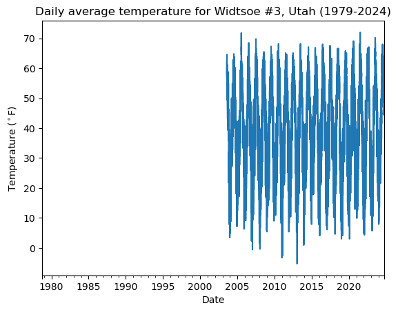

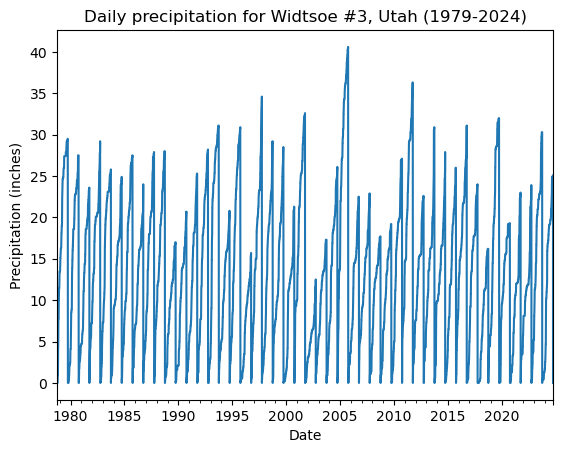

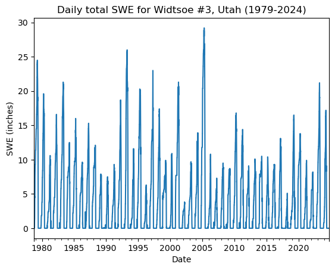

```python
# Plot the data using .plot. Initial exploration of data. Commented-out for final assignment
w3_df.plot(
    y='temp',
    title='Daily average temperature for Widtsoe #3, Utah (1979-2024)',
    xlabel='Date',
    ylabel='Temperature ($^\circ$F)',
    legend=False)
w3_df.plot(
    y='precip',
    title='Daily precipitation for Widtsoe #3, Utah (1979-2024)',
    xlabel='Date',
    ylabel='Precipitation (inches)',
    legend=False)
w3_df.plot(
    y='swe',
    title='Daily total SWE for Widtsoe #3, Utah (1979-2024)',
    xlabel='Date',
    ylabel='SWE (inches)',
    legend=False)
```

## Maxiumum snow water equivalent and annual precipitation

SNOTEL data from the Widtsoe #3 site was imported as daily data. To understand long-term trends in snow water equivalent (SWE ) and precipitation, the initial dataframe must be manipulated to provide annual maximum SWE accumulation and annual precipitation. Daily SWE and precipitation were recorded as SWE and precipitation acummulation since the start of the water year (October 1). To extract annual maximum SWE and annual precipitation, I used the .resample function by resampling the maximum SWE and precipitation value from each year.

```python
# Resample the DataFrame to get the maximum value for each year
w3_max_df = w3_df.resample('Y').max()
# Display the resulting DataFrame
#w3_max_df
```

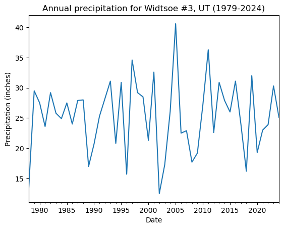

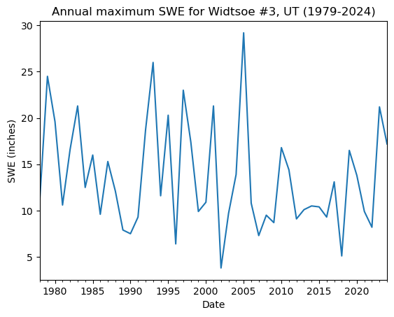

```python
# Plot the data using .plot

w3_max_df.plot(
    y='precip',
    title='Annual precipitation for Widtsoe #3, UT (1979-2024)',
    xlabel='Date',
    ylabel='Precipitation (inches)',
    legend=False)
w3_max_df.plot(
    y='swe',
    title='Annual maximum SWE for Widtsoe #3, UT (1979-2024)',
    xlabel='Date',
    ylabel='SWE (inches)',
    legend=False)
```